# Project1_Team5

SID: 490419197 | 490563375 | 490480360 | 470040090 | 490501230 | 470408935

Date: 07/11/2021

*Libraries used and preliminary data loading:*

```r
library(tidyverse)
library(dplyr)
library(ggplot2)
library(grid)
library(FactoMineR)
library(factoextra)
library(equatiomatic)
library(caret)
library(knitr)
library(corrplot)
library(rpart)
library(rpart.plot)
library(ggplot2)
library(cvms)
library(janitor)
library(arsenal)
require(survival)
options(scipen=999)
set.seed(1)

load("group_biom_v3.Rdata") #loading intermediate cleaned dataset just for convenience - will include cleaning process below, however, unexecuted.
```

*Preliminary cleaning process (note, here it is eval=FALSE for convenience) leading up to `group_biom_v3.Rdata`:*

```r
######## Initial Dataset Creation

load("tech_data.Rdata") #ABS dataset

dataset = subset(tech_biom, select = c(SABDYMS, BDYMSQ04, EXLWTBC, SEX, BMISC, PHDCMWBC, PHDCMHBC, PHDKGWBC)) #extract initial variables of interest

dataset$EXLWTBC = as.numeric(as.character(dataset$EXLWTBC)) #fix class type of exercise as it was originally factor

dataset1 = dataset[rowSums(is.na(dataset)) == 0,] #remove all rows with NA values

dataset1 = dataset1[dataset1$EXLWTBC != 9999, ] #remove placeholder values
dataset1 = dataset1[dataset1$EXLWTBC != 9996, ] #remove placeholder values

for (i in 1:nrow(dataset1)) {
  if (dataset1$SEX[i] == 1) {
    dataset1$RFM[i] = 64 - (20 * dataset1$PHDCMHBC[i] / dataset1$PHDCMWBC[i])
  }
  else if (dataset1$SEX[i] == 2) {
    dataset1$RFM[i] = 76 - (20 * dataset1$PHDCMHBC[i] / dataset1$PHDCMWBC[i])
  }
} #calculate RFM as needed

for (i in 1:nrow(dataset1)) {
  if (dataset1$SEX[i] == 1 && dataset1$RFM[i] < 2) {
    dataset1$RFM_Category[i] = 1
  }
  else if (dataset1$SEX[i] == 1 && dataset1$RFM[i] >= 2 && dataset1$RFM[i] < 5) {
    dataset1$RFM_Category[i] = 2
  }
  else if (dataset1$SEX[i] == 1 && dataset1$RFM[i] >= 5 && dataset1$RFM[i] < 13) {
    dataset1$RFM_Category[i] = 3
  }
  else if (dataset1$SEX[i] == 1 && dataset1$RFM[i] >= 13 && dataset1$RFM[i] < 17) {
    dataset1$RFM_Category[i] = 4
  }
  else if (dataset1$SEX[i] == 1 && dataset1$RFM[i] >= 17 && dataset1$RFM[i] < 24) {
    dataset1$RFM_Category[i] = 5
  }
  else if (dataset1$SEX[i] == 1 && dataset1$RFM[i] >= 25) {
    dataset1$RFM_Category[i] = 6
  }
  else if (dataset1$SEX[i] == 2 && dataset1$RFM[i] < 10) {
    dataset1$RFM_Category[i] = 1
  }
  else if (dataset1$SEX[i] == 2 && dataset1$RFM[i] >= 10 && dataset1$RFM[i] < 13) {
    dataset1$RFM_Category[i] = 2
  }
  else if (dataset1$SEX[i] == 2 && dataset1$RFM[i] >= 13 && dataset1$RFM[i] < 20) {
    dataset1$RFM_Category[i] = 3
  }
  else if (dataset1$SEX[i] == 2 && dataset1$RFM[i] >= 20 && dataset1$RFM[i] < 24) {
    dataset1$RFM_Category[i] = 4
  }
  else if (dataset1$SEX[i] == 2 && dataset1$RFM[i] >= 24 && dataset1$RFM[i] < 31) {
    dataset1$RFM_Category[i] = 5
  }
  else if (dataset1$SEX[i] == 2 && dataset1$RFM[i] >= 31) {
    dataset1$RFM_Category[i] = 6
  }
} #calculate RFM categories as needed

dataset2 = subset(dataset1, dataset1$RFM > 0) #remove RFM<0 since that doesn't make sense (only 2 entries so it's okay regardless)

dataset2$SABDYMS = droplevels(dataset2$SABDYMS) #remove unused levels
dataset2$BDYMSQ04 = droplevels(dataset2$BDYMSQ04) #remove unused levels


# recoding levels for intuitiveness and matching analysis
recode = c("Non-Overweight SP" = 1, "Non-Overweight SP" = 2, "Overweight SP" = 3)
dataset2$SABDYMS = factor(dataset2$SABDYMS, levels = recode, labels = names(recode))

recode2 = c("Male" = 1, "Female" = 2)
dataset2$SEX = factor(dataset2$SEX, levels = recode2, labels = names(recode2))

recode3 = c("Diet" = 1, "Diet" = 2, "Diet" = 3, "No-Diet" = 5)
dataset2$BDYMSQ04 = factor(dataset2$BDYMSQ04, levels = recode3, labels = names(recode3))

recode4 = c("Non-Obese" = 1, "Non-Obese" = 2, "Non-Obese" = 3, "Non-Obese" = 4, "Non-Obese" = 5, "Obese" = 6)
dataset2$RFM_Category = factor(dataset2$RFM_Category, levels = recode4, labels = names(recode4))
dataset2$RFM_Category = droplevels(as.factor(dataset2$RFM_Category))

# adding on accuracy of self-perception for later analysis (note this isn't used in step 1, only introduced until step 2)
for (i in 1:nrow(dataset2)) {
  if (dataset2$SABDYMS[i] == "Non-Overweight SP" && dataset2$RFM_Category[i] == "Non-Obese") {
    dataset2$`Self-Perception`[i] = "Accurate SP"
  }
  else if (dataset2$SABDYMS[i] == "Non-Overweight SP" && dataset2$RFM_Category[i] == "Obese") {
    dataset2$`Self-Perception`[i] = "Inaccurate SP"
  }
  else if (dataset2$SABDYMS[i] == "Overweight SP" && dataset2$RFM_Category[i] == "Obese") {
    dataset2$`Self-Perception`[i] = "Accurate SP"
  }
  else if (dataset2$SABDYMS[i] == "Overweight SP" && dataset2$RFM_Category[i] == "Non-Obese") {
    dataset2$`Self-Perception`[i] = "Inaccurate SP"
  }
}
dataset2$`Self-Perception` = as.factor(dataset2$`Self-Perception`) #changing from character to factor

# cleaning up dataset to contain only variables of analysis
dataset3 = subset(dataset2, select=c("Self-Perception", "SABDYMS", "SEX", "BDYMSQ04", "RFM", "PHDKGWBC", "EXLWTBC"))

#save(dataset3, file="group_biom_v3.Rdata")
```

## **Description of Data**

The data used throughout our analysis originates from the Australian Health Survey’s biomedical dataset from which we’ve extracted our respective variables of interest and cleaned. A summary has been tabulated below:

```r
variables = c(colnames(dataset3))
variables_definitions = data.frame(Variables = variables, Definitions = c(
  "Accuracy of Self-Perceived Weight Status",
  "Self-Perceived body mass / weight status",
  "Gender of person",
  "Whether currently on a diet",
  "Relative fat mass percentage as an indicator for obesity",
  "True measured weight in kilograms",
  "Total minutes of physical activity undertaken in past week"),
  Class = c("Factor", "Factor", "Factor", "Factor", "Numerical", "Numerical", "Numerical"),
  Levels = c("Accurate SP/Inaccurate SP", "Overweight SP/Non-Overweight SP", "Male/Female", "Diet/No-Diet", "Continuous", "Continuous", "Continuous"))
variables_definitions[nrow(variables_definitions)+1,] = "" #spacing for report
kable(variables_definitions, col.names = c("Variables", "Definitions", "Class", "Levels"), caption = "Fig 1: Summary table of variables and their definitions")
```

Fig 1: Summary table of variables and their definitions

| Variables | Definitions | Class | Levels |
| --- | --- | --- | --- |
| Self-Perception | Accuracy of Self-Perceived Weight Status | Factor | Accurate SP/Inaccurate SP |
| SABDYMS | Self-Perceived body mass / weight status | Factor | Overweight SP/Non-Overweight SP |
| SEX | Gender of person | Factor | Male/Female |
| BDYMSQ04 | Whether currently on a diet | Factor | Diet/No-Diet |
| RFM | Relative fat mass percentage as an indicator for obesity | Numerical | Continuous |
| PHDKGWBC | True measured weight in kilograms | Numerical | Continuous |
| EXLWTBC | Total minutes of physical activity undertaken in past week | Numerical | Continuous |

A snapshot can be seen in the following:

```r
kable(head(dataset3), caption = "Fig 2: Snapshot of working dataset")
```

Fig 2: Snapshot of working dataset

|  | Self-Perception | SABDYMS | SEX | BDYMSQ04 | RFM | PHDKGWBC | EXLWTBC |
| --- | --- | --- | --- | --- | --- | --- | --- |
| 1 | Inaccurate SP | Non-Overweight SP | Female | No-Diet | 31.81818 | 60.5 | 80 |
| 2 | Accurate SP | Overweight SP | Male | Diet | 30.29906 | 96.7 | 450 |
| 3 | Inaccurate SP | Non-Overweight SP | Female | No-Diet | 37.66667 | 63.2 | 190 |
| 4 | Inaccurate SP | Non-Overweight SP | Female | No-Diet | 31.87044 | 57.1 | 280 |
| 7 | Accurate SP | Non-Overweight SP | Female | No-Diet | 30.79452 | 68.3 | 360 |
| 10 | Inaccurate SP | Non-Overweight SP | Male | No-Diet | 31.39255 | 89.4 | 660 |

## **Analysis and Methodology**

### **Stage 1**

#### **Factor Analysis of Mixed Data**

Factor analysis of mixed data (FAMD) was selected as a model due to its accomodation for data that is comprised of both categorical and numerical data. Given that our selected dataset of interest is of such specification, FAMD was deemed appropriate for our purposes. As such, FAMD was performed on the initial variables - noting the removal of `Self-Perception` accuracy, due to irrelevance in stage 1, and `SABDYMS`, due to it being the response variable - to gather insights into the general explanatory and discriminatory power of each variable.

```r
PCA_dataset = dataset3
initial_variables = subset(PCA_dataset, select=-c(`Self-Perception`, SABDYMS))
initial_response = PCA_dataset$SABDYMS

res.famd = FAMD(initial_variables, graph=FALSE)
kable(round(get_eig(res.famd),3), caption="Fig 3: Principal component details")
```

Fig 3: Principal component details

|  | eigenvalue | variance.percent | cumulative.variance.percent |
| --- | --- | --- | --- |
| Dim.1 | 1.781 | 35.620 | 35.620 |
| Dim.2 | 1.284 | 25.684 | 61.304 |
| Dim.3 | 1.004 | 20.077 | 81.381 |
| Dim.4 | 0.813 | 16.266 | 97.647 |
| Dim.5 | 0.118 | 2.353 | 100.000 |

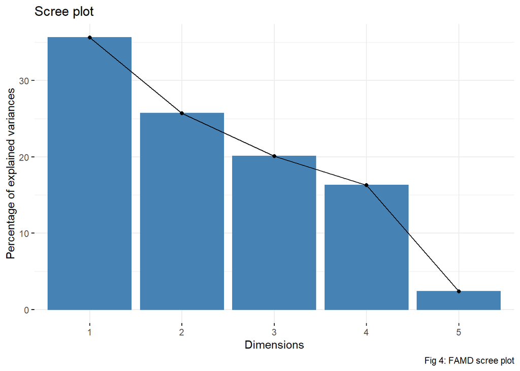

```r
fviz_screeplot(res.famd, caption="Fig 4: FAMD scree plot")
```

There are a couple of key notes here:

- The first three principal components were selected as relevant here due to their combined variance explanation of 81.4%, and how the third principal component - although slightly diminishing - was still deemed important due to its relatively close variance percentage to principal component 2.
- All our variables appear amongst the top three principal components, however, dietary status `BDYMSQ04` is notably less powerful according to FAMD compared to other variables as it fails to exceed 30%.
- The variance explanation distribution is not majorly dominated by the first principal component, only standing at a 35.6%. This implies a more distributed spread of explanatory power across the components, in our case, the top three components.

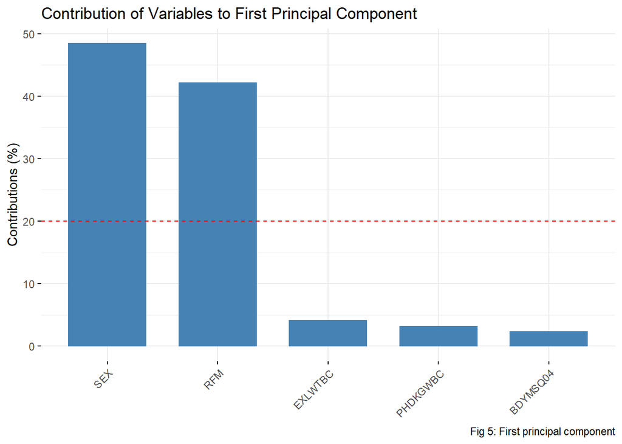

```r
fviz_contrib(res.famd, "var", axes = 1, title="Contribution of Variables to First Principal Component", caption="Fig 5: First principal component") # Contribution to the first dimension; gender+rfm = "gender obesity"
```

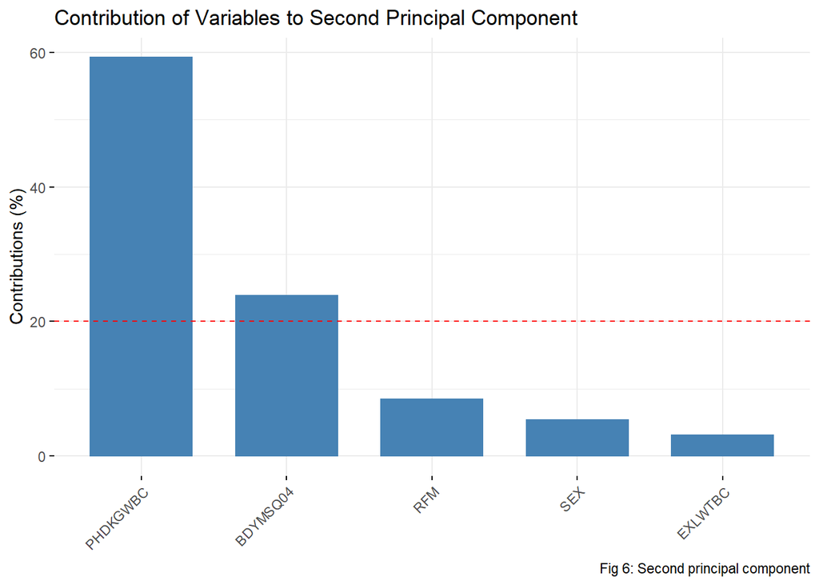

```r
fviz_contrib(res.famd, "var", axes = 2, title="Contribution of Variables to Second Principal Component", caption="Fig 6: Second principal component") # Contribution to the second dimension; true weight + diet = "behaviour"
```

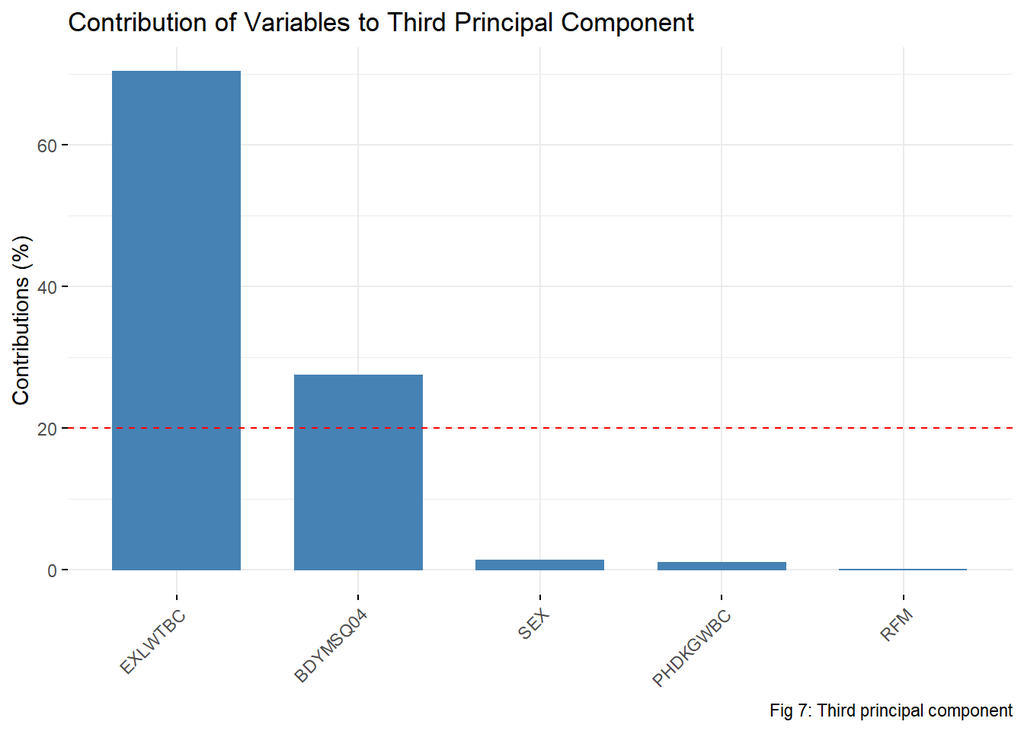

```r
fviz_contrib(res.famd, "var", axes = 3, title="Contribution of Variables to Third Principal Component", caption="Fig 7: Third principal component") # Contribution to the second dimension; exercise + diet = "lifestyle"
```

- The identities of these components can be seen above:
  - First principal component (PC1) represents a mixture of gender and relative fat mass.
  - Second principal component (PC2) represents a mixture of true weight and diet.
  - Third principal component (PC3) represents a mixture of exercise and diet.

```r
kable(round(res.famd$var$coord,3), caption="Fig 8: Principal component variable identities")
```

Fig 8: Principal component variable identities

|  | Dim.1 | Dim.2 | Dim.3 | Dim.4 | Dim.5 |
| --- | --- | --- | --- | --- | --- |
| RFM | 0.750 | 0.108 | 0.000 | 0.098 | 0.044 |
| PHDKGWBC | 0.056 | 0.761 | 0.010 | 0.152 | 0.021 |
| EXLWTBC | 0.073 | 0.040 | 0.706 | 0.182 | 0.000 |
| SEX | 0.862 | 0.069 | 0.013 | 0.004 | 0.052 |
| BDYMSQ04 | 0.041 | 0.307 | 0.275 | 0.378 | 0.000 |

Thus, visualising the FAMD into a two-dimensional plane of PC1 and PC2:

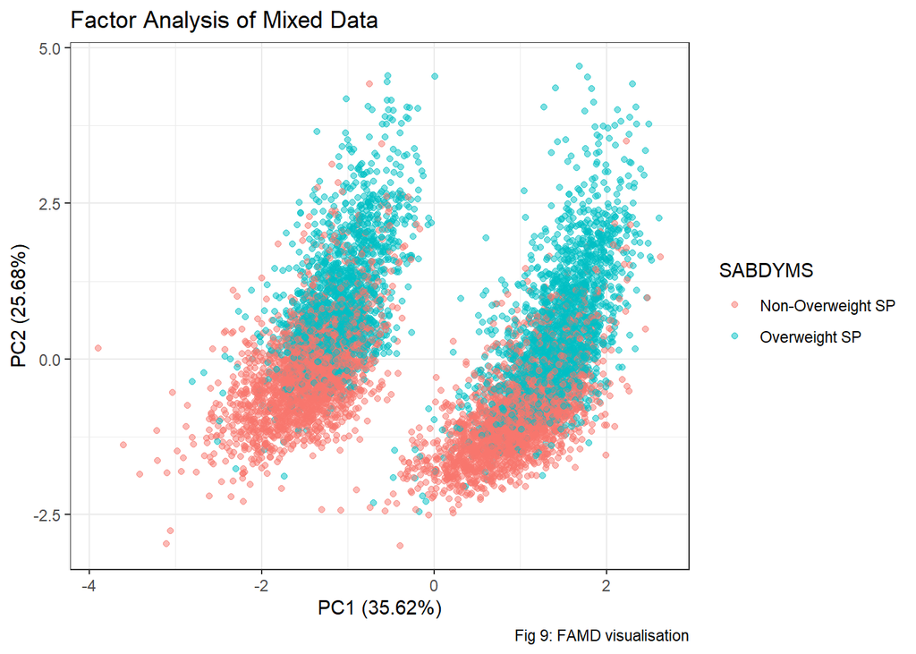

```r
PC1.ind <- res.famd$ind$coord[,1]; PC2.ind <- res.famd$ind$coord[,2]; PC3.ind <- res.famd$ind$coord[,3];
PC1.expl <- round(res.famd$eig[1,2],2); PC2.expl <- round(res.famd$eig[2,2],2); PC3.expl <- round(res.famd$eig[3,2],2);
labs.var<- rownames(res.famd$var$coord)

PCA_dataset$PC1.ind = PC1.ind
PCA_dataset$PC2.ind = PC2.ind
PCA_dataset$PC3.ind = PC3.ind


ggplot(PCA_dataset, aes(x=PC1.ind, y=PC2.ind, colour=SABDYMS)) +
  geom_point(alpha=0.5) + theme_bw() +
  xlab(paste('PC1 (',PC1.expl,'%',')', sep ='')) +
  ylab(paste('PC2 (',PC2.expl,'%',')', sep ='')) +
  labs(title="Factor Analysis of Mixed Data",
       caption="Fig 9: FAMD visualisation")
```

We can also observe how the categorical variables of dietary status and gender constitute these components:

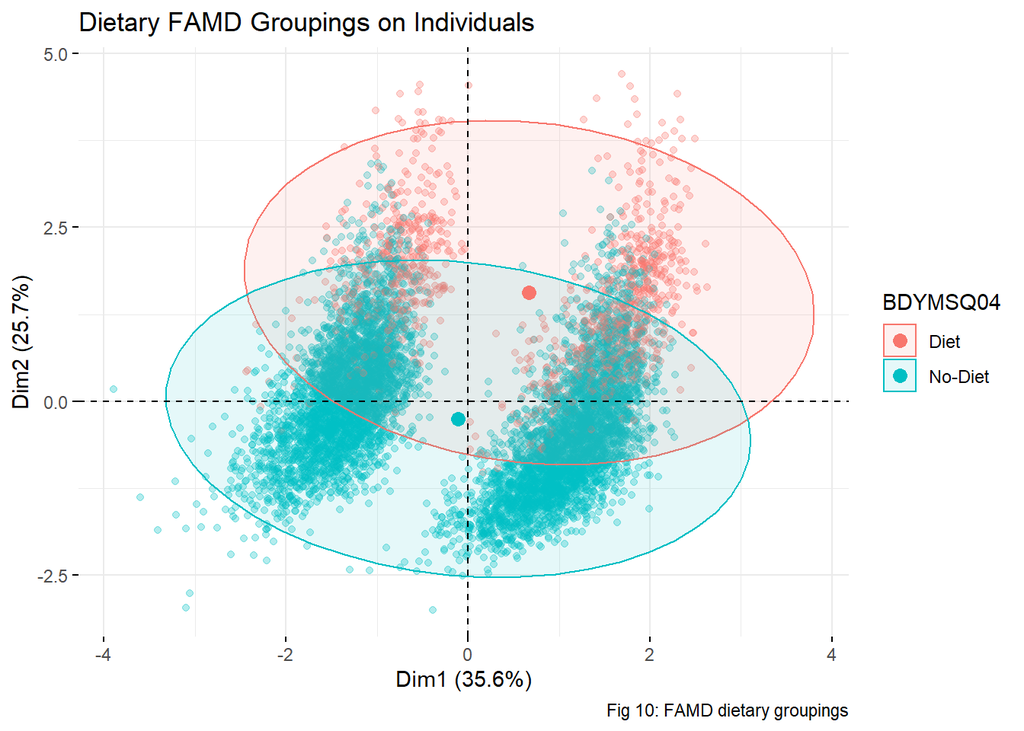

```r
fviz_mfa_ind(res.famd, habillage = "BDYMSQ04", geom = "point", alpha.ind = 0.3,
             addEllipses = TRUE, ellipse.level = 0.95, title = "Dietary FAMD Groupings on Individuals", caption="Fig 10: FAMD dietary groupings")
```

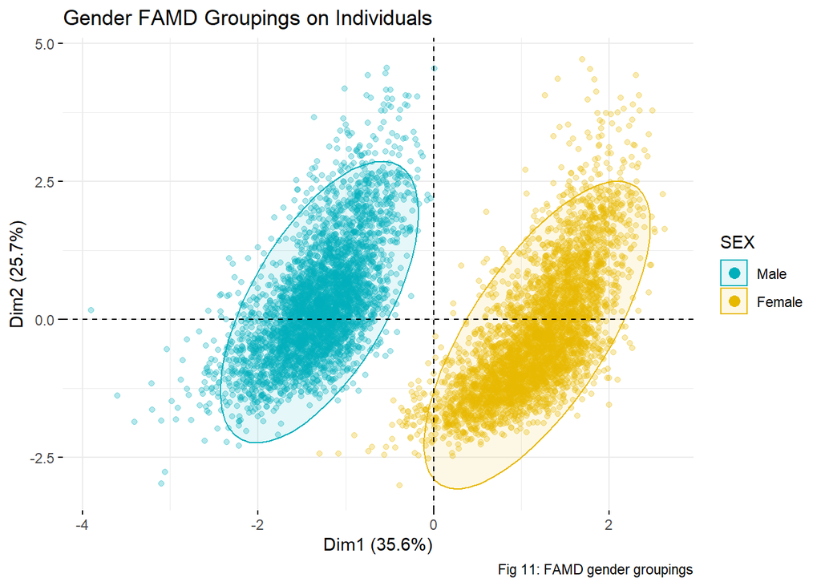

```r
fviz_mfa_ind(res.famd, habillage = "SEX", palette = c("#00AFBB", "#E7B800", "#FC4E07"), geom = "point", alpha.ind = 0.3, addEllipses = TRUE, ellipse.level = 0.95, title = "Gender FAMD Groupings on Individuals", caption="Fig 11: FAMD gender groupings")
```

#### **Standard Logistic Regression**

Standard logistic regression was performed here with `SABDYMS` - self-perceived weight status - as the response variable against the other predictors in the dataset (minus accuracy of self-perception as aforementioned stage 1 irrelevancy). Using a 50-repeat 5-cross-fold validation approach, the results are as follows:

```r
LR_dataset = subset(dataset3, select=-`Self-Perception`)

train_control = trainControl(method = "repeatedcv", number = 5, repeats=50)
logistic_model = train(SABDYMS~(.)^2, data=LR_dataset, trControl=train_control, method="glm", family=binomial())
coefficient_summary = summary(logistic_model)$coefficients
logistic_summary = data.frame("Variable" = rownames(coefficient_summary), "Coefficient" = round(coefficient_summary[,1],3), "Std. Error" = round(coefficient_summary[,2],3), "P-Value" = round(coefficient_summary[,4],3))
rownames(logistic_summary) = NULL
#contrasts(dataset3$SABDYMS) #0 = non-overweight SP, 1 = overweight SP
#logistic_model$results --> accuracy 0.8070316
logistic_summary2 = logistic_summary[order(-abs(logistic_summary$Coefficient)),]
kable(logistic_summary2, caption="Fig 12: Table of coefficients and significance")
```

Fig 12: Table of coefficients and significance

|  | Variable | Coefficient | Std..Error | P.Value |
| --- | --- | --- | --- | --- |
| 1 | (Intercept) | -17.957 | 1.969 | 0.000 |
| 3 | `BDYMSQ04No-Diet` | -2.617 | 0.820 | 0.001 |
| 7 | `SEXFemale:BDYMSQ04No-Diet` | 0.652 | 0.377 | 0.084 |
| 4 | RFM | 0.472 | 0.065 | 0.000 |
| 2 | SEXFemale | -0.231 | 0.718 | 0.748 |
| 8 | `SEXFemale:RFM` | -0.154 | 0.021 | 0.000 |
| 5 | PHDKGWBC | 0.139 | 0.022 | 0.000 |
| 9 | `SEXFemale:PHDKGWBC` | 0.062 | 0.010 | 0.000 |
| 12 | `BDYMSQ04No-Diet:PHDKGWBC` | 0.024 | 0.009 | 0.006 |
| 11 | `BDYMSQ04No-Diet:RFM` | -0.013 | 0.024 | 0.595 |
| 14 | `RFM:PHDKGWBC` | -0.003 | 0.001 | 0.000 |
| 6 | EXLWTBC | 0.001 | 0.001 | 0.297 |
| 10 | `SEXFemale:EXLWTBC` | -0.001 | 0.000 | 0.009 |
| 13 | `BDYMSQ04No-Diet:EXLWTBC` | 0.000 | 0.000 | 0.746 |
| 15 | `RFM:EXLWTBC` | 0.000 | 0.000 | 0.058 |
| 16 | `PHDKGWBC:EXLWTBC` | 0.000 | 0.000 | 0.001 |

We note that this has been performed with respect to inter-variable coefficients as well, in addition to single variable effects, due to our postulated inter-variable impacts that could affect an individual’s self-perception especially in a system as complex as the human body and lifestyle behaviours.

We further visualise this logistic model in two ways: firstly, we visualise the logistic model with respect to a baseline average RFM; and secondly, we visualise it with respect to a baseline average true weight. This allowed us to extract insights into the probabilistic effects of dietary status and gender on one’s probability of overweight self-perception:

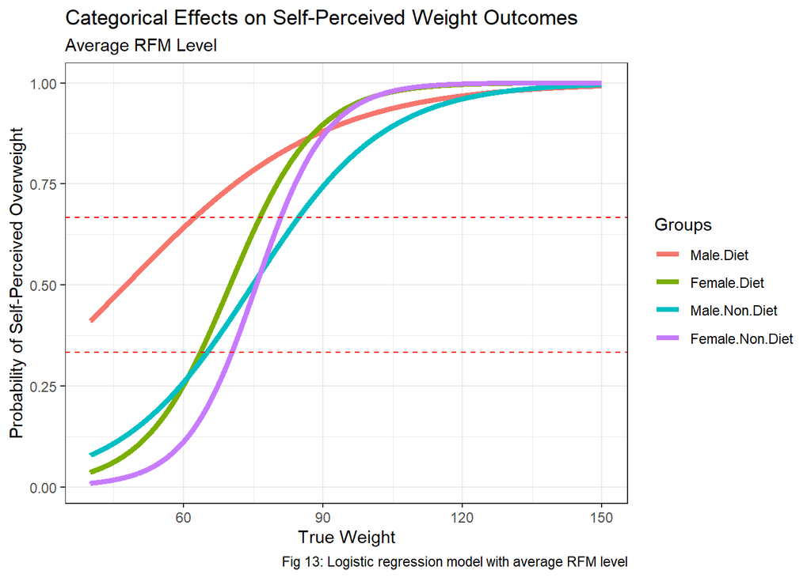

```r
# extracting the coefficients
constant = logistic_model$finalModel$coefficients[1]
Non_Diet = logistic_model$finalModel$coefficients[3]
exercise = logistic_model$finalModel$coefficients[6]
Female = logistic_model$finalModel$coefficients[2]
relative_fat_mass = logistic_model$finalModel$coefficients[4]
true_weight = logistic_model$finalModel$coefficients[5]
non_diet_exercise = logistic_model$finalModel$coefficients[13]
non_diet_female = logistic_model$finalModel$coefficients[7]
non_diet_rfm = logistic_model$finalModel$coefficients[11]
non_diet_true_weight = logistic_model$finalModel$coefficients[12]
exercise_female = logistic_model$finalModel$coefficients[10]
exercise_rfm = logistic_model$finalModel$coefficients[15]
exercise_true_weight = logistic_model$finalModel$coefficients[16]
female_rfm = logistic_model$finalModel$coefficients[8]
female_true_weight = logistic_model$finalModel$coefficients[9]
rfm_true_weight = logistic_model$finalModel$coefficients[14]


################################ a) true weight, rfm fundamental
X1_range = seq(from=min(LR_dataset$PHDKGWBC), to=max(LR_dataset$PHDKGWBC), by=.01) #setting up visualisation for true weight axis
X2_val = mean(LR_dataset$RFM) #setting up baseline average RFM

# calculating probabilities with respect to different dietary and gender combinations
Male_Diet_logits = constant + Non_Diet*0 + exercise + Female*0 + relative_fat_mass*X2_val + true_weight*X1_range +
  non_diet_exercise*0 + non_diet_female*0 + non_diet_rfm*X2_val*0 + non_diet_true_weight*X1_range*0 +
  exercise_female*0 + exercise_rfm*X2_val*1 + exercise_true_weight*X1_range*1 + female_rfm*X2_val*0 +
  female_true_weight*X1_range*0 + rfm_true_weight*X1_range*X2_val

Female_Diet_logits = constant + Non_Diet*0 + exercise + Female*1 + relative_fat_mass*X2_val + true_weight*X1_range +
  non_diet_exercise*0 + non_diet_female*0 + non_diet_rfm*X2_val*0 + non_diet_true_weight*X1_range*0 +
  exercise_female*1 + exercise_rfm*X2_val*1 + exercise_true_weight*X1_range*1 + female_rfm*X2_val*1 +
  female_true_weight*X1_range*1 + rfm_true_weight*X1_range*X2_val

Male_Non_Diet_logits = constant + Non_Diet*1 + exercise + Female*0 + relative_fat_mass*X2_val + true_weight*X1_range +
  non_diet_exercise*1 + non_diet_female*0 + non_diet_rfm*X2_val*1 + non_diet_true_weight*X1_range*1 +
  exercise_female*0 + exercise_rfm*X2_val*1 + exercise_true_weight*X1_range*1 + female_rfm*X2_val*0 +
  female_true_weight*X1_range*0 + rfm_true_weight*X1_range*X2_val

Female_Non_Diet_logits = constant + Non_Diet*1 + exercise + Female*1 + relative_fat_mass*X2_val + true_weight*X1_range +
  non_diet_exercise*1 + non_diet_female*1 + non_diet_rfm*X2_val*1 + non_diet_true_weight*X1_range*1 +
  exercise_female*1 + exercise_rfm*X2_val*1 + exercise_true_weight*X1_range*1 + female_rfm*X2_val*1 +
  female_true_weight*X1_range*1 + rfm_true_weight*X1_range*X2_val

Male_Diet_probs = exp(Male_Diet_logits)/(1 + exp(Male_Diet_logits))
Female_Diet_probs = exp(Female_Diet_logits)/(1 + exp(Female_Diet_logits))
Male_Non_Diet_probs = exp(Male_Non_Diet_logits)/(1 + exp(Male_Non_Diet_logits))
Female_Non_Diet_probs = exp(Female_Non_Diet_logits)/(1 + exp(Female_Non_Diet_logits))

plot.data = data.frame("Male Diet"=Male_Diet_probs, "Female Diet"=Female_Diet_probs,
                       "Male Non-Diet"=Male_Non_Diet_probs, "Female Non-Diet"=Female_Non_Diet_probs, X1=X1_range)

group = as.factor(c("Male.Diet", "Female.Diet", "Male.Non.Diet", "Female.Non.Diet"))
plot.data2 = data.frame(pivot_longer(plot.data, group, names_to = "Groups", values_to = c("prob")))
plot.data2$groups = as.factor(plot.data2$Groups)
plot.data2$Groups = factor(plot.data2$Groups, levels = c("Male.Diet", "Female.Diet", "Male.Non.Diet", "Female.Non.Diet"))

ggplot(plot.data2, aes(x=X1, y=prob, color=Groups)) +
  geom_line(lwd=1.5) + theme_bw() + geom_hline(yintercept=c(1/3, 2/3), linetype="dashed", color="red") +
  labs(x="True Weight", y="Probability of Self-Perceived Overweight",
       title="Categorical Effects on Self-Perceived Weight Outcomes",
       subtitle="Average RFM Level", caption="Fig 13: Logistic regression model with average RFM level")
```

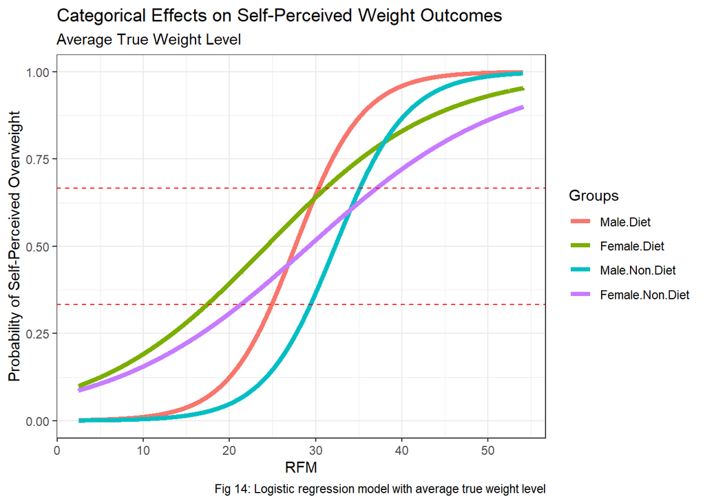

```r
################################ b) RFM, true weight fundamental
X1_range = seq(from=min(LR_dataset$RFM), to=max(LR_dataset$RFM), by=.01) #setting up visualisation for RFM axis
X2_val = mean(LR_dataset$PHDKGWBC) #setting up baseline average true weight

Male_Diet_logits = constant + Non_Diet*0 + exercise + Female*0 + relative_fat_mass*X1_range + true_weight*X2_val +
  non_diet_exercise*0 + non_diet_female*0 + non_diet_rfm*X1_range*0 + non_diet_true_weight*X2_val*0 +
  exercise_female*0 + exercise_rfm*X1_range*1 + exercise_true_weight*X2_val*1 + female_rfm*X1_range*0 +
  female_true_weight*X2_val*0 + rfm_true_weight*X1_range*X2_val

Female_Diet_logits = constant + Non_Diet*0 + exercise + Female*1 + relative_fat_mass*X1_range + true_weight*X2_val +
  non_diet_exercise*0 + non_diet_female*0 + non_diet_rfm*X1_range*0 + non_diet_true_weight*X2_val*0 +
  exercise_female*1 + exercise_rfm*X1_range*1 + exercise_true_weight*X2_val*1 + female_rfm*X1_range*1 +
  female_true_weight*X2_val*1 + rfm_true_weight*X1_range*X2_val

Male_Non_Diet_logits = constant + Non_Diet*1 + exercise + Female*0 + relative_fat_mass*X1_range + true_weight*X2_val +
  non_diet_exercise*1 + non_diet_female*0 + non_diet_rfm*X1_range*1 + non_diet_true_weight*X2_val*1 +
  exercise_female*0 + exercise_rfm*X1_range*1 + exercise_true_weight*X2_val*1 + female_rfm*X1_range*0 +
  female_true_weight*X2_val*0 + rfm_true_weight*X1_range*X2_val

Female_Non_Diet_logits = constant + Non_Diet*1 + exercise + Female*1 + relative_fat_mass*X1_range + true_weight*X2_val +
  non_diet_exercise*1 + non_diet_female*1 + non_diet_rfm*X1_range*1 + non_diet_true_weight*X2_val*1 +
  exercise_female*1 + exercise_rfm*X1_range*1 + exercise_true_weight*X2_val*1 + female_rfm*X1_range*1 +
  female_true_weight*X2_val*1 + rfm_true_weight*X1_range*X2_val

Male_Diet_probs = exp(Male_Diet_logits)/(1 + exp(Male_Diet_logits))
Female_Diet_probs = exp(Female_Diet_logits)/(1 + exp(Female_Diet_logits))
Male_Non_Diet_probs = exp(Male_Non_Diet_logits)/(1 + exp(Male_Non_Diet_logits))
Female_Non_Diet_probs = exp(Female_Non_Diet_logits)/(1 + exp(Female_Non_Diet_logits))

plot.data = data.frame("Male Diet"=Male_Diet_probs, "Female Diet"=Female_Diet_probs,
                       "Male Non-Diet"=Male_Non_Diet_probs, "Female Non-Diet"=Female_Non_Diet_probs, X1=X1_range)

group = as.factor(c("Male.Diet", "Female.Diet", "Male.Non.Diet", "Female.Non.Diet"))
plot.data2 = data.frame(pivot_longer(plot.data, group, names_to = "Groups", values_to = c("prob")))
plot.data2$groups = as.factor(plot.data2$Groups)
plot.data2$Groups = factor(plot.data2$Groups, levels = c("Male.Diet", "Female.Diet", "Male.Non.Diet", "Female.Non.Diet"))

ggplot(plot.data2, aes(x=X1, y=prob, color=Groups)) +
  geom_line(lwd=1.5) + theme_bw() + geom_hline(yintercept=c(1/3, 2/3), linetype="dashed", color="red") +
  labs(x="RFM", y="Probability of Self-Perceived Overweight",
       title="Categorical Effects on Self-Perceived Weight Outcomes",
       subtitle="Average True Weight Level", caption="Fig 14: Logistic regression model with average true weight level")
```

#### **FAMD/PCA Logistic Regression**

Integrating the principal components into a logistic regression, also using 50-repeat 5-cross-fold validation approach, we aimed to evaluate the ability for logistic regression to accurately predict self-perceived overweightness. This would provide additional insights into the apparent strengths of our personal and lifestyle variables in explaining overweight self-perceptions.

```r
PCA_LR_dataset = data.frame("response" = initial_response, "PC1" = PC1.ind, "PC2" = PC2.ind, "PC3" = PC3.ind)
PCA_logistic_model = train(response ~ PC1 + PC2 + PC3, data=PCA_LR_dataset, trControl=train_control, method="glm", family=binomial())
#PCA_logistic_model$results --> accuracy is 0.7832372
PCA_coefficient_summary = summary(PCA_logistic_model)$coefficients
PCA_logistic_summary = data.frame("Variable" = rownames(PCA_coefficient_summary), "Coefficient" = round(PCA_coefficient_summary[,1],3),
                              "Std. Error" = round(PCA_coefficient_summary[,2],3), "P-Value" = round(PCA_coefficient_summary[,4],3))
rownames(PCA_logistic_summary) = NULL

PCA_logistic_summary2 = PCA_logistic_summary[order(-abs(PCA_logistic_summary$Coefficient)),]
kable(PCA_logistic_summary2, caption="Fig 15: Table of coefficients and significance")
```

Fig 15: Table of coefficients and significance

|  | Variable | Coefficient | Std..Error | P.Value |
| --- | --- | --- | --- | --- |
| 3 | PC2 | 1.608 | 0.039 | 0 |
| 2 | PC1 | 0.516 | 0.024 | 0 |
| 1 | (Intercept) | -0.200 | 0.030 | 0 |
| 4 | PC3 | -0.128 | 0.033 | 0 |

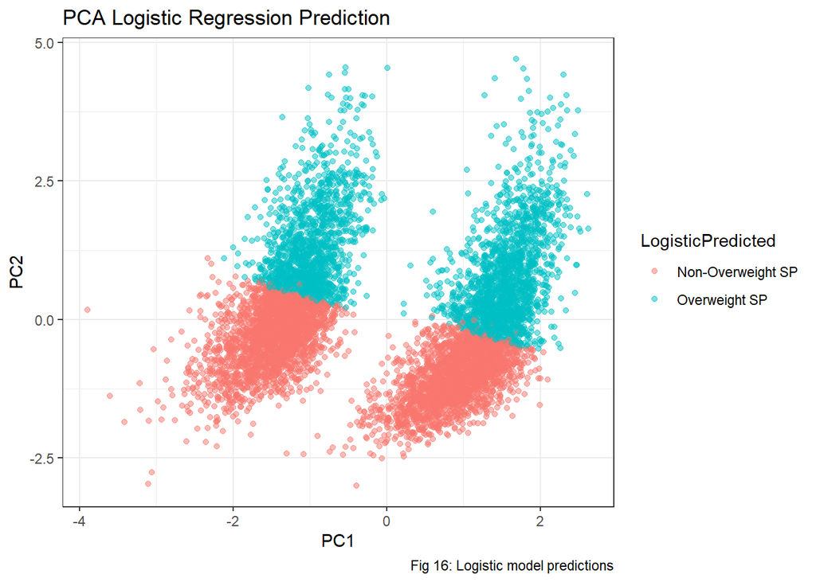

```r
#contrasts(PCA_LR_dataset$response) #0 = non-overweight, 1 = overweight
PCA_LR_dataset$LogisticPredictedRaw = PCA_logistic_model$finalModel$fitted.values
PCA_LR_dataset$LogisticPredicted = NA

for (i in 1:nrow(PCA_LR_dataset)) {
  if (PCA_LR_dataset$LogisticPredictedRaw[i] >= 0.5) {
    PCA_LR_dataset$LogisticPredicted[i] = "Overweight SP"
  }
  else {
    PCA_LR_dataset$LogisticPredicted[i] = "Non-Overweight SP"
  }
}

PCA_LR_dataset$LogisticAccuracy = ifelse(PCA_LR_dataset$response == PCA_LR_dataset$LogisticPredicted, "Accurate", "Inaccurate")
PCA_LR_dataset$LogisticAccuracy = as.factor(PCA_LR_dataset$LogisticAccuracy)
PCA_LR_dataset$LogisticAccuracy = factor(PCA_LR_dataset$LogisticAccuracy, levels = c("Inaccurate", "Accurate"))
PCA_LR_dataset$alpha = ifelse(PCA_LR_dataset$LogisticAccuracy=="Inaccurate", 1, 0.5)


ggplot(PCA_LR_dataset, aes(x=PC1, y=PC2, colour=LogisticPredicted)) +
  geom_point(alpha=0.5) + theme_bw() + labs(title="PCA Logistic Regression Prediction", caption="Fig 16: Logistic model predictions")
```

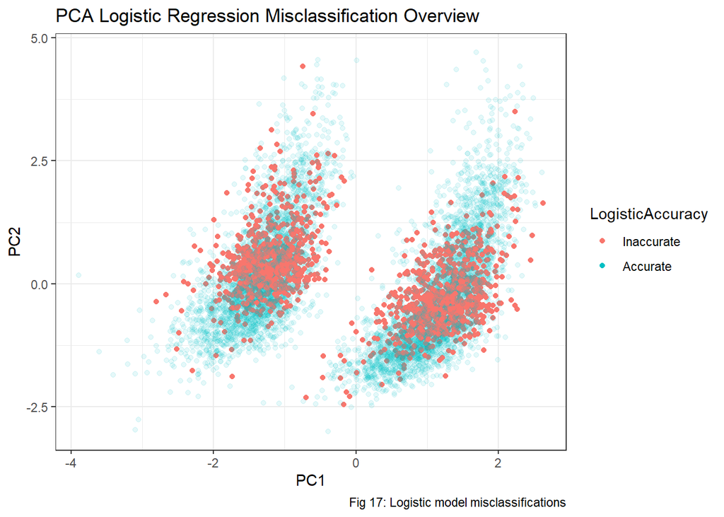

```r
ggplot(PCA_LR_dataset, aes(x=PC1, y=PC2, colour=LogisticAccuracy, alpha=alpha)) +
  geom_point() + theme_bw() + labs(title="PCA Logistic Regression Misclassification Overview", caption="Fig 17: Logistic model misclassifications") + scale_alpha(guide="none")
```

So while the PCA logistic model produced quite a generic and fine-line classification model, its actual error is non-negligible with majority of misclassifications occurring near the centre areas of each principal component. This suggests that the model struggles to accurately predict self-perception near the boundary of each principal component - an idea that leads us to stage 2 where we try to identify the nature of these boundaries.

### **Stage 2**

#### **Standard Logistic Regression**

Returning back to our aforementioned new variable `Self-Perception`, indicating whether an individual accurately or inaccurately self-perceived their weight status, we repeat a standard logistic regression model (50-repeat, 5-cross-fold validation, with AIC optimisation) to try and predict `Self-Perception`, observing the coefficients and significance of variables and inter-variable relationships to identify key distinctions between the two groups.

```r
step2_dataset = subset(dataset3, select=-c(SABDYMS)) #remove SABDYMS due to near-perfect information
#step_LR_model = train(`Self-Perception` ~ (.)^2, data = step2_dataset, trControl = train_control, method="glmStepAIC", family=binomial(), trace=FALSE)
#save(step_LR_model, file="step2_logistic_regression.Rdata")
load("step2_logistic_regression.Rdata") #cached cus it takes too long to run every time
#step_LR_model$results --> accuracy is 0.7612

#contrasts(step2_dataset$`Self-Perception`) #0 = accurate, 1 = inaccurate

step2_coefficient_summary = summary(step_LR_model)$coefficients
step2_logistic_summary = data.frame("Variable" = rownames(step2_coefficient_summary), "Coefficient" = round(step2_coefficient_summary[,1],3),
                              "Std. Error" = round(step2_coefficient_summary[,2],3), "P-Value" = round(step2_coefficient_summary[,4],3))
rownames(step2_logistic_summary) = NULL

step2_logistic_summary2 = step2_logistic_summary[order(-abs(step2_logistic_summary$Coefficient)),]
kable(step2_logistic_summary2, caption="Fig 18: Table of coefficients and significance")
```

Fig 18: Table of coefficients and significance

|  | Variable | Coefficient | Std..Error | P.Value |
| --- | --- | --- | --- | --- |
| 1 | (Intercept) | -28.498 | 1.289 | 0.000 |
| 6 | `SEXFemale:BDYMSQ04No-Diet` | -1.764 | 0.332 | 0.000 |
| 3 | RFM | 1.083 | 0.051 | 0.000 |
| 2 | SEXFemale | 1.023 | 0.544 | 0.060 |
| 4 | PHDKGWBC | 0.346 | 0.017 | 0.000 |
| 7 | `SEXFemale:RFM` | -0.255 | 0.017 | 0.000 |
| 10 | `BDYMSQ04No-Diet:RFM` | 0.124 | 0.019 | 0.000 |
| 8 | `SEXFemale:PHDKGWBC` | 0.098 | 0.008 | 0.000 |
| 11 | `BDYMSQ04No-Diet:PHDKGWBC` | -0.033 | 0.006 | 0.000 |
| 12 | `RFM:PHDKGWBC` | -0.013 | 0.001 | 0.000 |
| 5 | EXLWTBC | -0.003 | 0.001 | 0.000 |
| 9 | `SEXFemale:EXLWTBC` | -0.001 | 0.000 | 0.062 |
| 13 | `RFM:EXLWTBC` | 0.000 | 0.000 | 0.000 |

#### **Classification Tree**

Due to our variable of interest being qualitative we decided to use “Classification tree” to predict “Self-perception”. Classification Trees used for predicting qualitative variables oppose to Decision Trees also predictor variables could be qualitative and quantitative.

```r
# note that the following sections were performed independently, so some code may repeat in nature
load("group_biom_v3.rdata")
for (i in 1:nrow(dataset3)) {
  if (dataset3$SEX[i] == "Male" && dataset3$RFM[i] < 2) {
    dataset3$RFM_Category[i] = 0
  }
  else if (dataset3$SEX[i] == "Male" && dataset3$RFM[i] >= 2 && dataset3$RFM[i] < 5) {
    dataset3$RFM_Category[i] = 0
  }
  else if (dataset3$SEX[i] == "Male" && dataset3$RFM[i] >= 5 && dataset3$RFM[i] < 13) {
    dataset3$RFM_Category[i] = 0
  }
  else if (dataset3$SEX[i] == "Male" && dataset3$RFM[i] >= 13 && dataset3$RFM[i] < 17) {
    dataset3$RFM_Category[i] = 0
  }
  else if (dataset3$SEX[i] == "Male" && dataset3$RFM[i] >= 17 && dataset3$RFM[i] < 24) {
    dataset3$RFM_Category[i] = 0
  }
  else if (dataset3$SEX[i] == "Male" && dataset3$RFM[i] >= 25) {
    dataset3$RFM_Category[i] = 1
  }
  else if (dataset3$SEX[i] == "Female" && dataset3$RFM[i] < 10) {
    dataset3$RFM_Category[i] = 0
  }
  else if (dataset3$SEX[i] == "Female" && dataset3$RFM[i] >= 10 && dataset3$RFM[i] < 13) {
    dataset3$RFM_Category[i] = 0
  }
  else if (dataset3$SEX[i] == "Female" && dataset3$RFM[i] >= 13 && dataset3$RFM[i] < 20) {
    dataset3$RFM_Category[i] = 0
  }
  else if (dataset3$SEX[i] == "Female" && dataset3$RFM[i] >= 20 && dataset3$RFM[i] < 24) {
    dataset3$RFM_Category[i] = 0
  }
  else if (dataset3$SEX[i] == "Female" && dataset3$RFM[i] >= 24 && dataset3$RFM[i] < 31) {
    dataset3$RFM_Category[i] = 0
  }
  else if (dataset3$SEX[i] == "Female" && dataset3$RFM[i] >= 31) {
    dataset3$RFM_Category[i] = 1
  }
}

recode3 = c("Obese" = 1, "Non-Obese" = 0)
dataset3$RFM_Category = factor(dataset3$RFM_Category, levels = recode3, labels = names(recode3))

df = dataset3

df$"Self-Perception" = as.factor(df$"Self-Perception")
df$"RFM_Category" = as.factor(df$"RFM_Category")
names(df)[1] <- "SELFPERC"
```

Splitting data into training and test set with 70/30, 70 percent of the data to train the model and 30 percent to make predictions.

```r
df = subset(df, select = -c(SABDYMS, RFM_Category) )
set.seed(2021)
dt = sort(sample(nrow(df), nrow(df)*.7))
train1<-df[dt,]
test1<-df[-dt,]
```

#### Cross-Validation:

Smaller Complexity Parameter (cp) gives accurate tree with less X-val Relative Error.

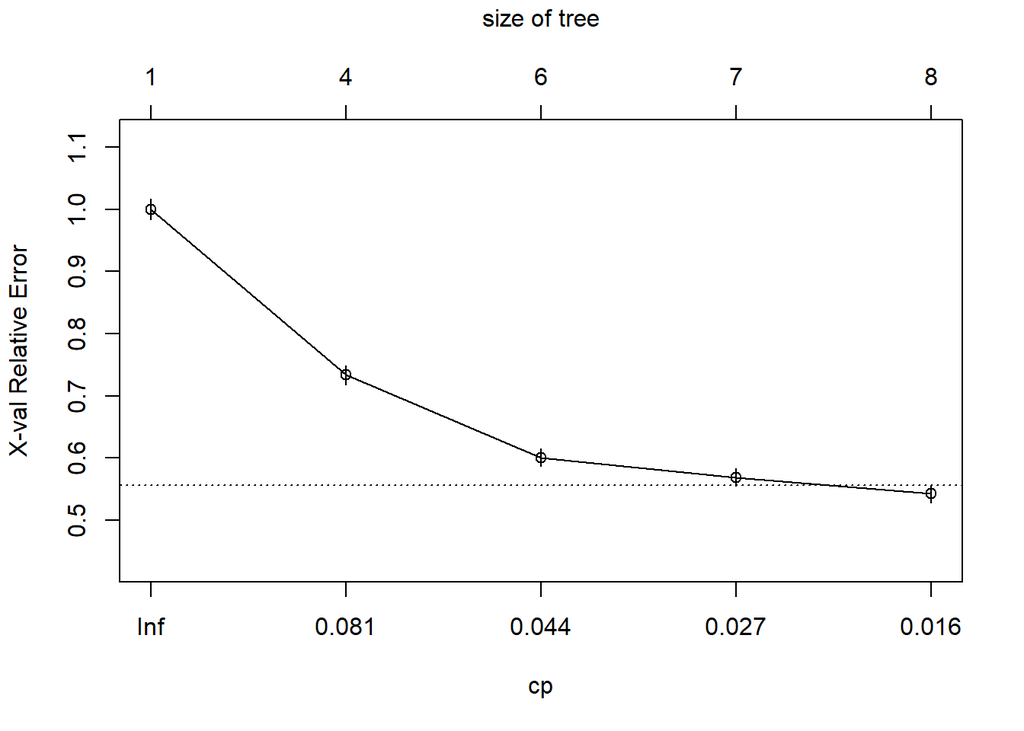

Fig 19: Cross-Validation result graph

```r
res1 <- rpart(SELFPERC~.,data=train1,
              parms = list(split="information"))
plotcp(res1, upper = "size")
```

Complexity Parameter table:

```r
knitr::kable(round(tab1,3), caption = "Fig 20: Table of Complexity Parameter")
```

Fig 20: Table of Complexity Parameter

| CP | nsplit | rel error | xerror | xstd |
| --- | --- | --- | --- | --- |
| 0.099 | 0 | 1.000 | 1.000 | 0.017 |
| 0.067 | 3 | 0.700 | 0.733 | 0.015 |
| 0.029 | 5 | 0.567 | 0.601 | 0.015 |
| 0.025 | 6 | 0.538 | 0.569 | 0.014 |
| 0.010 | 7 | 0.513 | 0.543 | 0.014 |

#### Classification Tree:

The variables actually used for the tree are PHDKGWBC ~ Actual Weight, SEX, RFM ~ Relative Fat Mass, the number of observations in each node is displayed along.

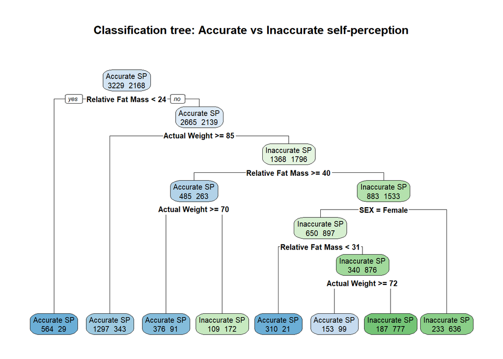

Fig 21: Classification Tree

```r
split.fun <- function(x, labs, digits, varlen, faclen)
{
    labs   <- sub("PHDKGWBC",   "Actual Weight", labs)
    labs   <- sub("RFM",      "Relative Fat Mass", labs)
    labs
}
rpart.plot(res1, extra = 1, split.fun = split.fun, main = "Classification tree: Accurate vs Inaccurate self-perception")
```

The Predicted tree suggests that majority (3229) observations fell into accurate “Self-Perception” category. Whereas 2168 observations classified as inaccurate “Self-Perception”. RFM more than 40 and Actual Weight less than 70 -> inaccurate, FEMALE who has RFM between 31 - 40 and Actual Weight of less than 72 -> inaccurate, MALE who has RFM between 24-40 and Actual Weight less than 85 -> inaccurate.

Setting Complexity Parameter to zero to get full tree without performing pruning using cp.

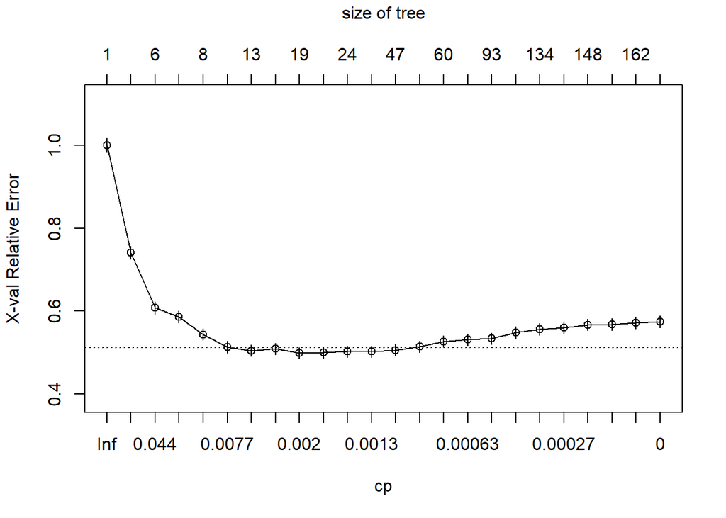

Fig 22: Cross-Validation result graph for full tree

```r
rpart_cont <- rpart.control(cp = 0)
res2 <- rpart(SELFPERC~.,data=train1,
              control = rpart_cont,
              parms = list(split="information"))
plotcp(res2)
```

```r
tb <- data.frame(res2$cptable)
knitr::kable(tb, caption = "Fig 23: Table of Complexity Parameter of Full Tree")
```

Fig 23: Table of Complexity Parameter of Full Tree

| CP | nsplit | rel.error | xerror | xstd |
| --- | --- | --- | --- | --- |
| 0.0987085 | 0 | 1.0000000 | 1.0000000 | 0.0166122 |
| 0.0666513 | 3 | 0.7001845 | 0.7403137 | 0.0154895 |
| 0.0290590 | 5 | 0.5668819 | 0.6074723 | 0.0145542 |
| 0.0249077 | 6 | 0.5378229 | 0.5853321 | 0.0143703 |
| 0.0092251 | 7 | 0.5129151 | 0.5433579 | 0.0139972 |
| 0.0064576 | 9 | 0.4944649 | 0.5129151 | 0.0137054 |
| 0.0027675 | 12 | 0.4746310 | 0.5041513 | 0.0136179 |
| 0.0020756 | 16 | 0.4630996 | 0.5087638 | 0.0136642 |
| 0.0018450 | 18 | 0.4589483 | 0.4986162 | 0.0135618 |
| 0.0016144 | 21 | 0.4534133 | 0.4995387 | 0.0135712 |
| 0.0013838 | 23 | 0.4501845 | 0.5023063 | 0.0135993 |
| 0.0011531 | 29 | 0.4395756 | 0.5023063 | 0.0135993 |
| 0.0009225 | 46 | 0.4178967 | 0.5055351 | 0.0136318 |
| 0.0007688 | 53 | 0.4109779 | 0.5138376 | 0.0137145 |
| 0.0006919 | 59 | 0.4063653 | 0.5262915 | 0.0138359 |
| 0.0005766 | 73 | 0.3966790 | 0.5309041 | 0.0138801 |
| 0.0004613 | 92 | 0.3837638 | 0.5332103 | 0.0139020 |
| 0.0003459 | 127 | 0.3639299 | 0.5484317 | 0.0140441 |
| 0.0003075 | 133 | 0.3616236 | 0.5562731 | 0.0141155 |
| 0.0002306 | 136 | 0.3607011 | 0.5599631 | 0.0141487 |
| 0.0001977 | 147 | 0.3570111 | 0.5668819 | 0.0142103 |
| 0.0001538 | 154 | 0.3556273 | 0.5678044 | 0.0142185 |
| 0.0000577 | 161 | 0.3537823 | 0.5710332 | 0.0142469 |
| 0.0000000 | 169 | 0.3533210 | 0.5742620 | 0.0142751 |

Using information below we get full tree.

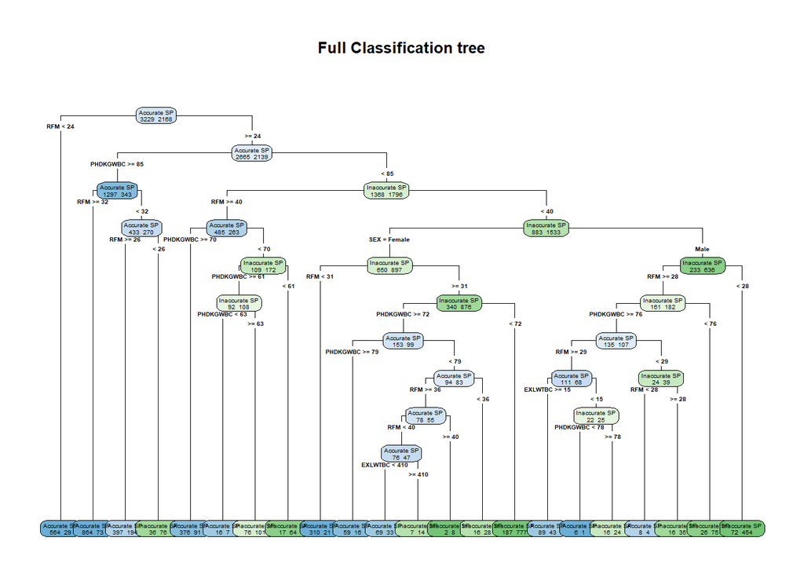

Fig 24: Full Classification Tree graph

```r
res3 <- prune.rpart(res2, cp = 0.0018)
rpart.plot(res3,type=4,extra=1, main="Full Classification tree",cex=0.3)
```

#### Caret Package: Cross-Validation

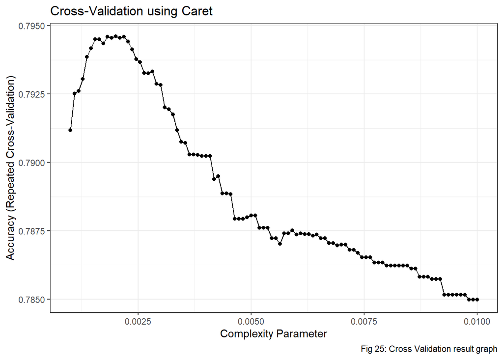

```r
n_grid <- 100
tuneGrid <- expand.grid(cp = seq(0.01, 0.001, length=n_grid))
res4 <- train(
  SELFPERC ~ .,
  data = train1,
  method = "rpart",
  trControl = trainControl(method = "repeatedcv",
                           number = 10,
                           repeats = 10),
  tuneGrid = tuneGrid)
ggplot(res4) +  theme_bw() + labs(title = "Cross-Validation using Caret", caption = "Fig 25: Cross Validation result graph")
```

```r
min_val <- which.min(res4$results$Accuracy)
opt_cv  <- res4$results$cp[min_val]
```

#### Classification Tree:

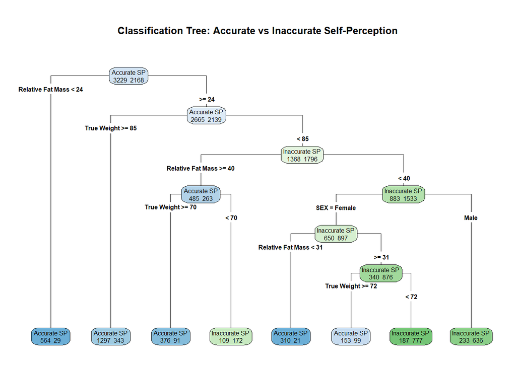

Fig 26: Final Classification Tree

```r
res5 <- prune.rpart(res2, cp = opt_cv)
split.fun <- function(x, labs, digits, varlen, faclen)
{
    labs   <- sub("PHDKGWBC",   "True Weight", labs)
    labs   <- sub("RFM",      "Relative Fat Mass", labs)
    labs
}
rpart.plot(res5,type=4,extra=1, main="Classification Tree: Accurate vs Inaccurate Self-Perception",cex=0.5, split.fun = split.fun)
```

- True Weight less than 70; and Relative Fat Mass (RFM) more than 40 -> inaccurate
- True Weight less than 85; Relative Fat Mass (RFM) between 24 - 40; and Male -> inaccurate
- True Weight less than 72; Relative Fat Mass (RFM) between 31 - 40; and Female -> inaccurate

#### Confusion Matrix:

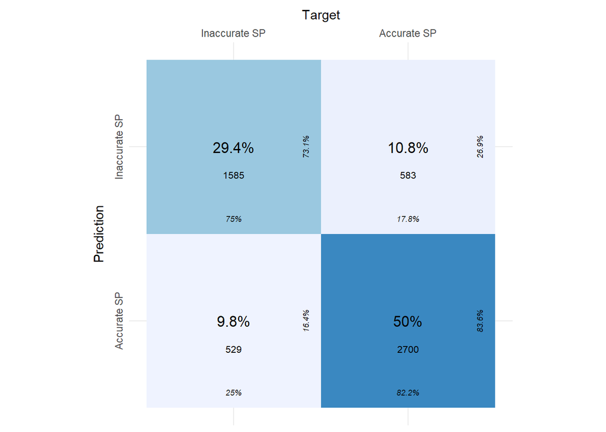

Fig 27: Confusion Matrix of Training set

```r
cfm = confusionMatrix(train1$SELFPERC,
                predict(res5,
                        newdata=train1,
                        type="class"))

cfm1 <- as_tibble(cfm$table)
plot_confusion_matrix(cfm1,
                      target_col = "Reference",
                      prediction_col = "Prediction",
                      counts_col = "n")
```

```r
kable(confusionMatrix(train1$SELFPERC,
                predict(res5,
                        newdata=train1,
                        type="class"))$overall[1], caption = "Fig 28: Accuracy of Confusion Matrix")
```

Fig 28: Accuracy of Confusion Matrix

|  | x |
| --- | --- |
| Accuracy | 0.7939596 |

#### Test vs Train set model

Comparing test and train set with increasing size of tree along with value of error.

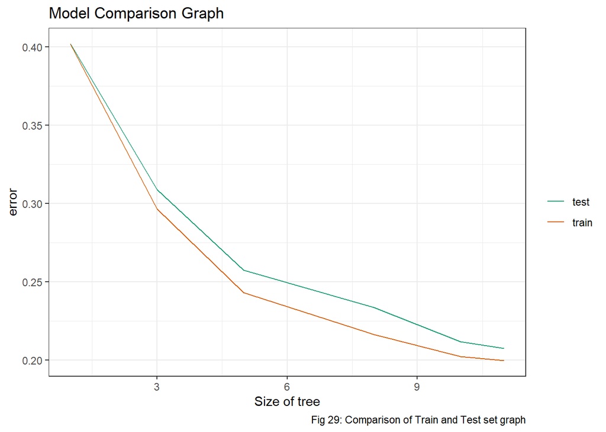

### **Tabulation**

Tabulation was the final stage of our analysis, and featured simple tables of our data.

```r
df = dataset3

df$"Self-Perception" = as.factor(df$"Self-Perception")
df$"RFM_Category" = as.factor(df$"RFM_Category")
names(df)[1] <- "SELFPERC"
tab1 <- tableby(SABDYMS ~ SEX + RFM_Category + BDYMSQ04, data=df)

kable(summary(tab1), caption = "Fig 30: Tabulation of Variables vs Self-Perception")
```

Fig 30: Tabulation of Variables vs Self-Perception

|  | Non-Overweight SP (N=4257) | Overweight SP (N=3454) | Total (N=7711) | p value |
| --- | --- | --- | --- | --- |
| **SEX** |  |  |  | < 0.001 |
| Male | 2111 (49.6%) | 1552 (44.9%) | 3663 (47.5%) |  |
| Female | 2146 (50.4%) | 1902 (55.1%) | 4048 (52.5%) |  |
| **RFM_Category** |  |  |  | < 0.001 |
| Obese | 3020 (70.9%) | 3376 (97.7%) | 6396 (82.9%) |  |
| Non-Obese | 1237 (29.1%) | 78 (2.3%) | 1315 (17.1%) |  |
| **BDYMSQ04** |  |  |  | < 0.001 |
| Diet | 321 (7.5%) | 748 (21.7%) | 1069 (13.9%) |  |
| No-Diet | 3936 (92.5%) | 2706 (78.3%) | 6642 (86.1%) |  |

The first table featured groupings by self-perception as a whole from stage 1 analysis.

```r
tab2 <- tableby(SELFPERC ~ SEX + RFM_Category + BDYMSQ04, data=df)
kable(summary(tab2), caption = "Fig 31: Tabulation of Variables vs Accuracy of Self-Perception")
```

Fig 31: Tabulation of Variables vs Accuracy of Self-Perception

|  | Accurate SP (N=4613) | Inaccurate SP (N=3098) | Total (N=7711) | p value |
| --- | --- | --- | --- | --- |
| **SEX** |  |  |  | < 0.001 |
| Male | 2265 (49.1%) | 1398 (45.1%) | 3663 (47.5%) |  |
| Female | 2348 (50.9%) | 1700 (54.9%) | 4048 (52.5%) |  |
| **RFM_Category** |  |  |  | < 0.001 |
| Obese | 3376 (73.2%) | 3020 (97.5%) | 6396 (82.9%) |  |
| Non-Obese | 1237 (26.8%) | 78 (2.5%) | 1315 (17.1%) |  |
| **BDYMSQ04** |  |  |  | < 0.001 |
| Diet | 800 (17.3%) | 269 (8.7%) | 1069 (13.9%) |  |
| No-Diet | 3813 (82.7%) | 2829 (91.3%) | 6642 (86.1%) |  |

The second table featured groupings by accuracy of self-perception from stage 2 analysis.